# DATA1001 Project

Author

540539824, 550668899, 440318530, 541006846, 530657501

# Recommendation/Insight

Student’s rent prices rose slightly between 2024S2 and 2025S1, with higher averages and wider variation. However, commute time showed only a weak link to rent. This suggests students can’t rely on moving farther away to save money—other factors like transport access and area preferences influence housing costs.

# Evidence

## IDA

This dataset was collected from a voluntary, self-reported survey by students, previously or currently enrolled in DATA1X01 at the University of Sydney.

Our analysis focused on three variables: weekly rent paid (AUD), commute time to campus (minutes), and student cohort (2024S2 or 2025S1). The first two are quantitative and continuous, while cohort is a categorical variable with two levels.

The dataset only includes DATA1X01 students and does not represent the University of Sydney student body or the general student population in Sydney. As the data was self-reported and unverified, it may be inaccurate due to misinterpretation or estimation error.

We assumed that respondents provided reasonable estimates of their weekly rent and commute times. A rent value of $0 was interpreted as students living with family or in rent-free arrangements, and these were excluded as they do not reflect market rent. Values above $2000 per week were also excluded, as they may represent shared leases, data-entry errors, or luxury rentals outside the typical student range. Commute times over 180 minutes were excluded as well, with 3 hours set as a generous upper limit for daily commute.

```r
library(tidyverse)      # for box and linear model
library(ggthemes)       # for ggplot theme

surveydata = read.csv("data1001_survey_data_2025_S1.csv")
surveydata = filter(surveydata, consent == "I consent to take part in the study") # remove students who did not consent to take part in the study
surveydata = surveydata[surveydata$rent <= 2000, ]    # remove data with rent greater than 2000
surveydata = surveydata[surveydata$rent != 0, ]       # remove data with 0 rent
surveydata = surveydata[surveydata$commute <= 180, ]  # remove data with commute time greater than 180 minutes
```

## Research Question 1

**How have rent prices changed between Semester 2 of last year (2024) and Semester 1 this year (2025) ?**

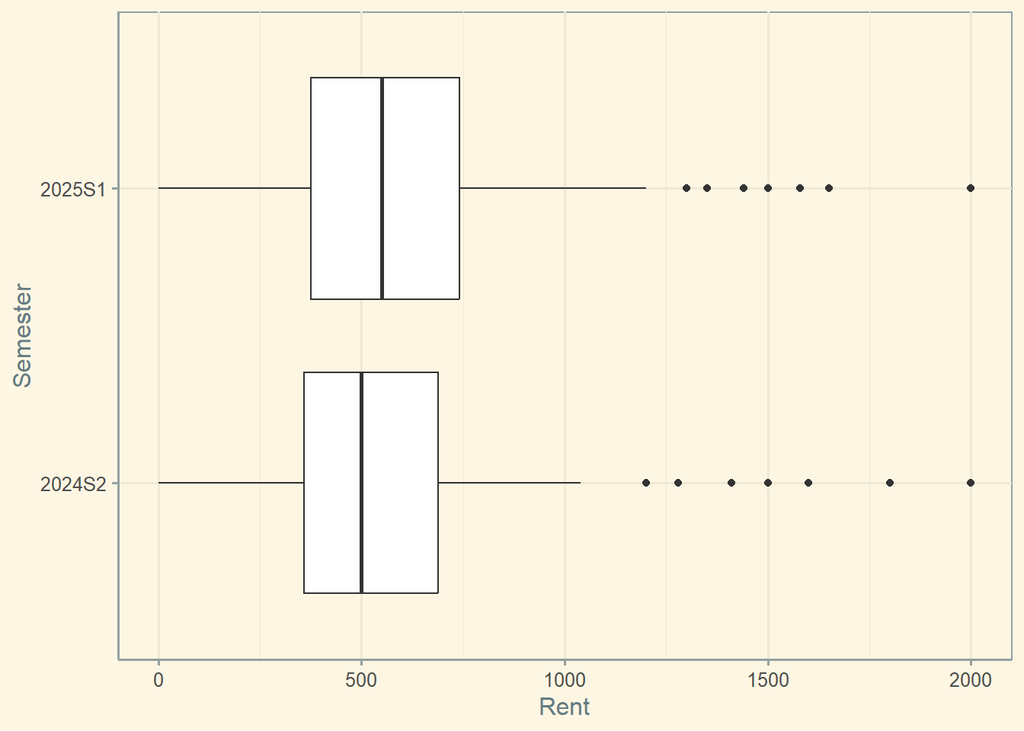

```r
ggplot(surveydata, aes(x = rent, y = cohort)) +
  geom_boxplot() +
  labs(x = "Rent",
       y = "Semester") +
  theme_solarized() +
  scale_fill_solarized()
```

Rent prices for 2025S1 students increased compared to 2024S2. In particular, the median rent rose from $500 to $550, while the mean increased from $526.83 to $557.46. The interquartile range (IQR) also increased from $328 to $366. Together, these changes suggest inflation in rent prices and greater variation in the amount students are paying. This may be due to affordability pressures and increased demand for more realistic housing options, such as rental units (KPMG, 2025).

However, data limitations such as the significantly different sample sizes (597 in 2024S2 vs. 1506 in 2025S1) and the short time frame of two semesters prevent the analysis of long-term trends. Additionally, responses reporting $0 were excluded, as we assumed these students live with their parents or in other rent-free arrangements. These cases do not align with our research question.

## Research Question 2

**Is there a linear correlation between the rent a student pays and the time they commute for?**

**Scatter Plot**

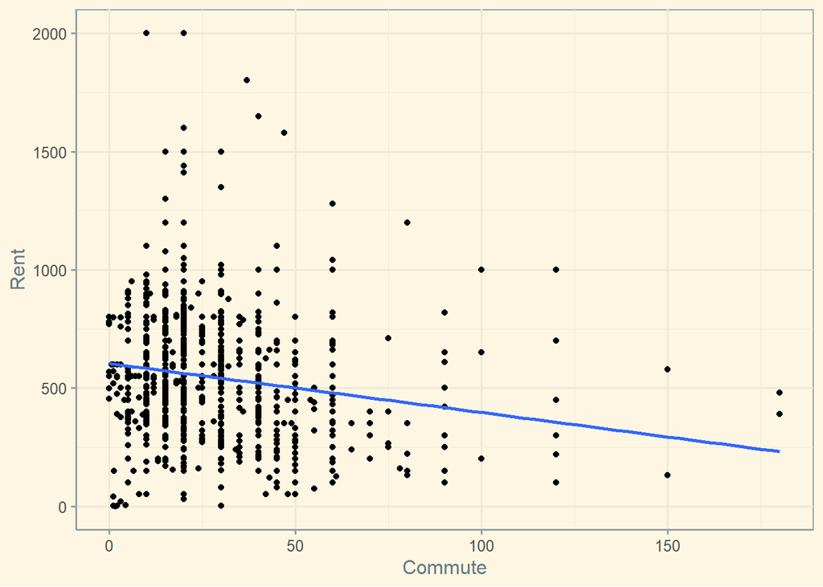

```r
ggplot(surveydata, aes(x = commute, y = rent)) +
  geom_point() +
  geom_smooth(method = "lm", se = FALSE) +
  labs(x = "Commute",
       y = "Rent") +
  theme_solarized() +
  scale_fill_solarized()
```

**Residual Plot**

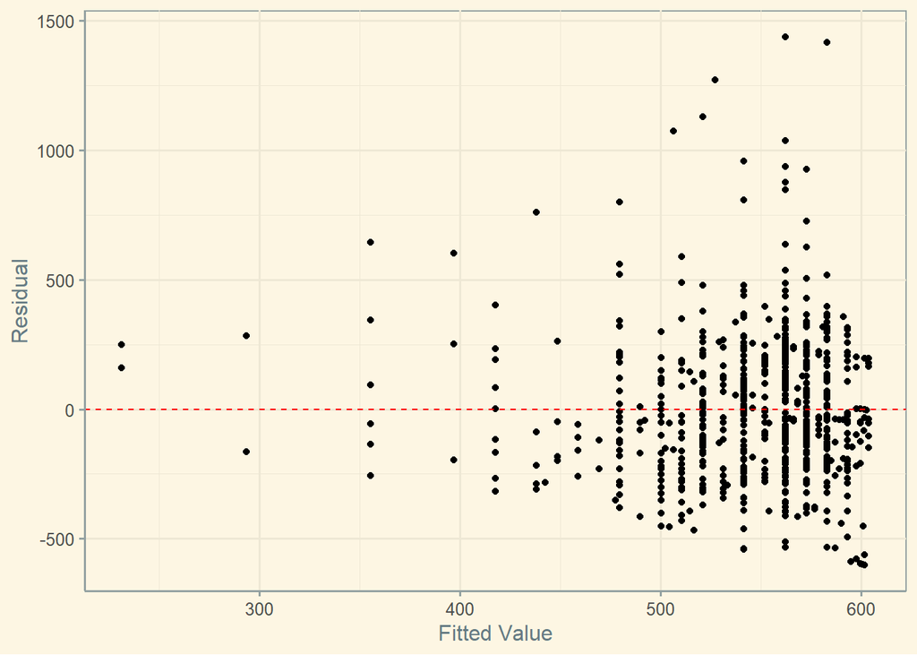

```r
model = lm(rent ~ commute, data = surveydata)

# Create residual plot
# Create residual plot
ggplot(model, aes(x = .fitted, y = .resid)) +
  geom_point() +
  geom_hline(yintercept = 0, linetype = "dashed", colour = "red") +
  labs(x = "Fitted Value",
        y = "Residual") +
  theme_solarized() +
  scale_fill_solarized()
```

There is a very weak negative correlation between commute time and rental prices among students in the DATA1001 unit. This is evident from our linear model graph. The scatter plot lacks a clear linear pattern, and the correlation coefficient of -0.17 suggests the association between the variables is negligible. The residual plot also shows clustered points and a lack of homoscedasticity, indicating that a linear model is not appropriate for this data.

Average rent in downtown Sydney ranges between $600–$1,200 per week, while rents in Western and South-Western Sydney tend to average around $400–$550 per week (Soho, 2025). It is logical to expect that students living farther from campus, and thus commuting longer, would pay lower rent. However, our findings did not reflect a strong or consistent pattern. The relationship between rent and commute time is likely too complex to explain with a single factor, as things like transport access, availability of affordable housing, and personal preferences also influence rental prices (Herath & Jayasekare, 2021).

# Articles

Our RQ1 findings reflect KPMG’s projection that unit rent prices will rise by 4.6% in 2025, driven by ongoing affordability pressures and increased demand for lower-cost housing. RQ2 supports Herath and Jayasekare’s conclusion that travel time alone cannot explain rent patterns, as other factors like accessibility and amenities also matter.

# Professional standard of report

We upheld integrity by accurately reporting our findings, avoiding data manipulation, and acknowledging limitations in our analysis. We protected interests of subjects by excluding non-consenting responses.

# Acknowledgements

**Group Meetings & Attendance**

- Wednesday 26/3 (in class): Yousuf, Vyom, Carleen — brainstormed research questions
- Wednesday 2/4 (in class): Carleen, Diya, Alex, Vyom — selected key questions, including RQ2
- Thursday 3/4 (5:00–6:30pm call): Carleen, Alex, Yousuf — Alex plotted RQ1, Carleen wrote IDA and Q1 analysis, Yousuf sourced articles
- Friday 4/4 (1:00–2:00pm call): Carleen, Alex, Diya — Alex found reference article for Q1, Carleen refined analysis, Diya and Alex started Q2, Diya wrote insight
- Wednesday 9/4 (in class): Carleen, Alex, Yousuf, Vyom — Carleen completed Q1 & Q2 with references, Vyom worked on IDA, Alex updated QMD
- Friday 11/4 (1:00pm call): Vyom, Alex, Yousuf — shortened final sections, reviewed marking criteria, finalised acknowledgements

**Group Member Contributions**

- Carleen: IDA write-up, Q1 and Q2 analysis, integrating references, presentation slides
- Alex: Plots for Q1 and Q2, statistical summaries (mean, median, IQR), QMD formatting
- Diya: Wrote insight and recommendation for Q2, assisted with Q2 analysis
- Vyom: IDA contribution, brainstormed questions, reviewed final structure,completed professional standard of report, completed article section, final edits to Q1 and Q2.
- Yousuf: Rewrote Q2 analysis, sourced relevant articles, assisted with editing and final criteria check

**Resources used**

- Shared github repository: https://github.com/aspartamealex/DATA1001
- Shared google doc was used to collaborate on making the report.

**AI Usage Statement**

We did not use AI for this project, and our ideas were original.

# References

Herath, S., & Jayasekare, T. (2021). City proximity, travel modes and house prices: Evidence from Sydney. Journal of Housing and the Built Environment, 36(1), 211–229. https://doi.org/10.1007/s10901-020-09805-w

KPMG. (2025, January). House and unit prices to rise in 2025. https://kpmg.com/au/en/home/media/press-releases/2025/01/house-and-unit-prices-to-rise-in-2025.html

Soho. (2025). Average rent in Sydney. https://soho.com.au/articles/average-rent-in-sydney